# Unit 02 Project

Zayanah Rasyamond

2026-02-04

```r
penguins <- penguins %>%
  drop_na(flipper_length_mm, body_mass_g, bill_length_mm, bill_depth_mm, sex)
```

#Q1 This makes the background of the plot white. Biscoe has the most penguins.

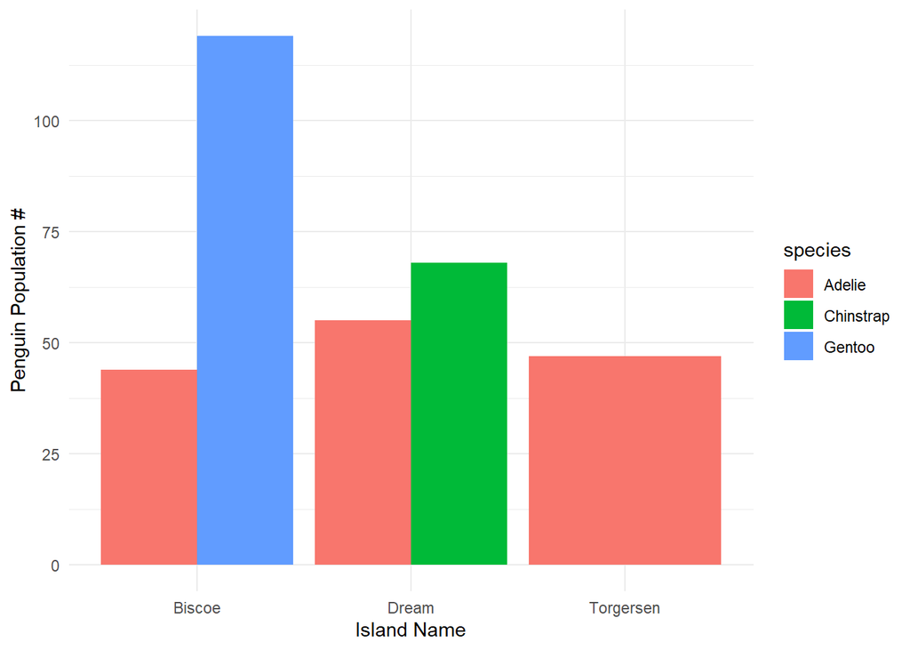

```r
ggplot(data = penguins, aes(x = island, fill = species)) +
         geom_bar(position = "dodge") +
          labs(x = "Island Name", y = "Penguin Population #") +
  theme_minimal()
```

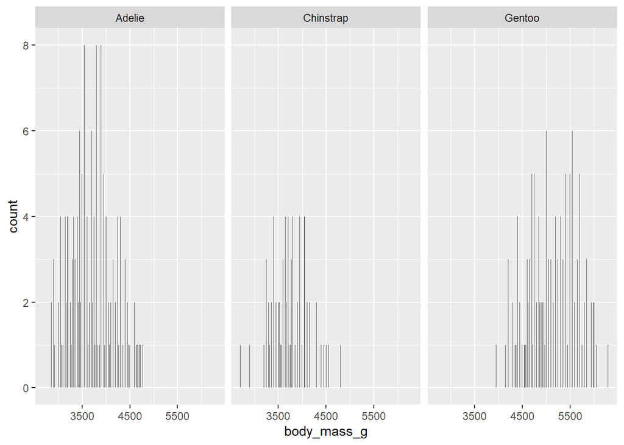

```r
ggplot(data = penguins, aes(x = body_mass_g)) +
  geom_histogram(binwidth = 10) +
  facet_wrap(~ species)
```

```r
  labs(x = "Body Mass (g)", y = "Count (#)") +
  theme_minimal(base_size = 21)
```

#Q3 Gentoo penguins have the longest flippers. Males tend to have a higher body mass.The fill helps with readability because it colors each box plot, making it more eye catching.

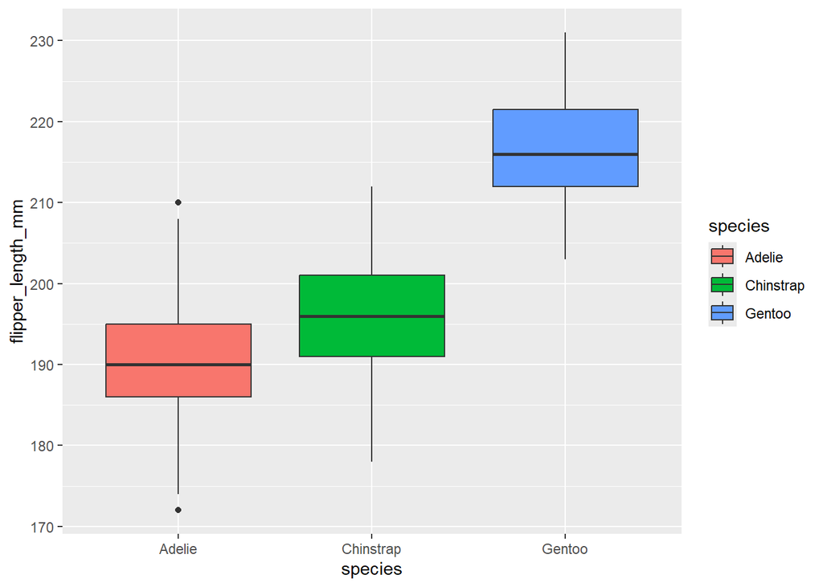

```r
ggplot(data = penguins, aes(x = species, y = flipper_length_mm, fill = species)) +
  geom_boxplot()
```

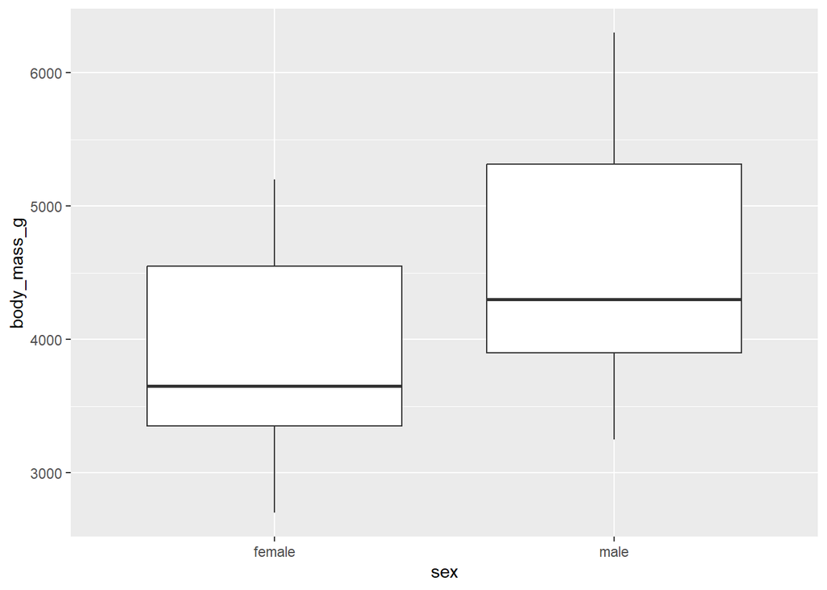

```r
ggplot(data = penguins, aes(x = sex, y = body_mass_g)) +
  geom_boxplot()
```

#Q4 The relationship is initially unclear because all the points are the same color. However, after using color = species, I can interpret that the relationship seems positive. The line fits the data well as it reflects this positive relationship.

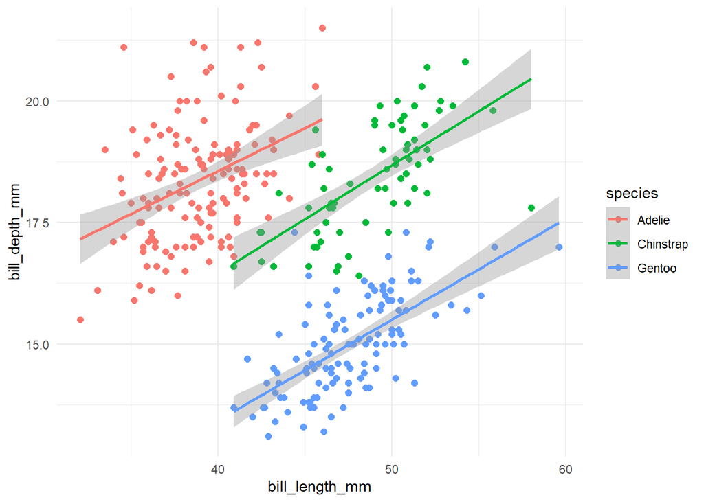

```r
ggplot(data = penguins, aes(x = bill_length_mm, y = bill_depth_mm, color = species)) +
 geom_point(size = 2) +
   theme_minimal() +
    geom_smooth(method = "lm")
```

#Q5 Gentoo penguins seem to show the strongest relationship. After using the facet_grid function, it seems that the group with the strongest positive correlation would be the male Chinstrap penguins.

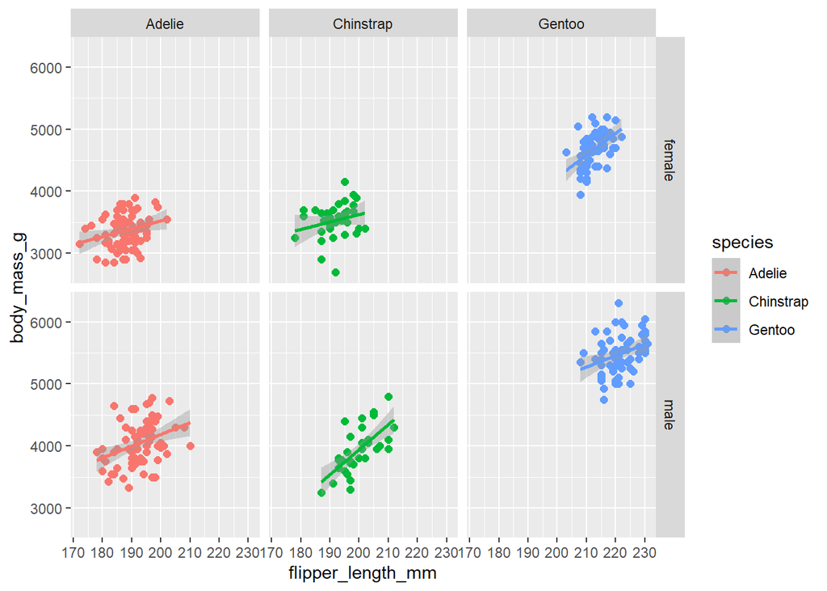

```r
ggplot(data = penguins, aes(x = flipper_length_mm, y = body_mass_g, color = species)) +
  geom_point(size = 2) +
  facet_wrap(~species) +
   geom_smooth(method = "lm") +
  facet_grid(sex~species)
```

```r
  theme_minimal()
```

[output not shown]

[output cut: 313 more lines]

[output not shown]

#Q6

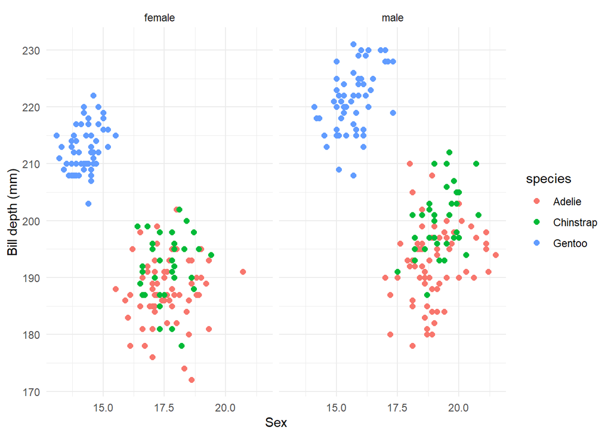

```r
ggplot(data = penguins, aes(x = bill_depth_mm, y = flipper_length_mm, color = species)) +
  geom_point(size = 2) +
  facet_wrap(~sex) +
  labs(x = "Sex", y = "Bill depth (mm)") +
  theme_minimal()
```

#Q7 It was most fun to be able to color the plots however I wanted. It is confusing to figure out what some of the more obscure and non self explanatory functions are used for; like facet wrap.

| #Lecture 07 |
| --- |
| #Lecture 08 |

```r
library(tidyverse)
library(palmerpenguins)
penguins <- palmerpenguins::penguins
```

#Q1 The original data set has 344 rows, while the cleaned data set has 333 rows.

```r
penguins_clean <- penguins %>%
  drop_na(bill_length_mm, sex)

nrow(penguins_clean)
```

```
## [1] 333
```

```r
nrow(penguins)
```

```
## [1] 344
```

#Q2 The number after duplication is 363, and after using distinct, the total number of rows is 333. Duplicates can cause error in summary statistics and plots because they may create an inaccurate overrepresentation of certain data points, which would alter data trends and further analyses.

```r
penguins_dup <- penguins_clean %>%
  bind_rows(slice_sample(penguins_clean, n = 30, replace = TRUE))
nrow(penguins_dup)
```

```
## [1] 363
```

```r
penguins_dup %>% distinct %>% nrow
```

```
## [1] 333
```

#Q3 There are 8 columns in the data frame.

```r
penguins_clean %>%
  select(species, island, sex, where(is.numeric))
```

```
## # A tibble: 333 × 8
##    species island    sex    bill_length_mm bill_depth_mm flipper_length_mm
##    <fct>   <fct>     <fct>           <dbl>         <dbl>             <int>
##  1 Adelie  Torgersen male             39.1          18.7               181
##  2 Adelie  Torgersen female           39.5          17.4               186
##  3 Adelie  Torgersen female           40.3          18                 195
##  4 Adelie  Torgersen female           36.7          19.3               193
##  5 Adelie  Torgersen male             39.3          20.6               190
##  6 Adelie  Torgersen female           38.9          17.8               181
##  7 Adelie  Torgersen male             39.2          19.6               195
##  8 Adelie  Torgersen female           41.1          17.6               182
##  9 Adelie  Torgersen male             38.6          21.2               191
## 10 Adelie  Torgersen male             34.6          21.1               198
## # ℹ 323 more rows
## # ℹ 2 more variables: body_mass_g <int>, year <int>
```

```r
ncol(penguins_clean)
```

```
## [1] 8
```

#Q4

```r
penguins_clean %>%
  select(starts_with("bill"))
```

```
## # A tibble: 333 × 2
##    bill_length_mm bill_depth_mm
##             <dbl>         <dbl>
##  1           39.1          18.7
##  2           39.5          17.4
##  3           40.3          18
##  4           36.7          19.3
##  5           39.3          20.6
##  6           38.9          17.8
##  7           39.2          19.6
##  8           41.1          17.6
##  9           38.6          21.2
## 10           34.6          21.1
## # ℹ 323 more rows
```

```r
penguins_clean %>%
  select(ends_with("_mm"))
```

```
## # A tibble: 333 × 3
##    bill_length_mm bill_depth_mm flipper_length_mm
##             <dbl>         <dbl>             <int>
##  1           39.1          18.7               181
##  2           39.5          17.4               186
##  3           40.3          18                 195
##  4           36.7          19.3               193
##  5           39.3          20.6               190
##  6           38.9          17.8               181
##  7           39.2          19.6               195
##  8           41.1          17.6               182
##  9           38.6          21.2               191
## 10           34.6          21.1               198
## # ℹ 323 more rows
```

```r
penguins_clean %>%
  select(matches("bi.*|fli.*"))
```

```
## # A tibble: 333 × 3
##    bill_length_mm bill_depth_mm flipper_length_mm
##             <dbl>         <dbl>             <int>
##  1           39.1          18.7               181
##  2           39.5          17.4               186
##  3           40.3          18                 195
##  4           36.7          19.3               193
##  5           39.3          20.6               190
##  6           38.9          17.8               181
##  7           39.2          19.6               195
##  8           41.1          17.6               182
##  9           38.6          21.2               191
## 10           34.6          21.1               198
## # ℹ 323 more rows
```

#Q5 Using across(where(is.numeric)) is much more efficient than typing out every numeric column name, because there may be a very large number of these columns and this will be useful for large datasets.

```r
penguins_clean %>%
  group_by(species) %>%
  summarize(across(where(is.numeric), mean))
```

```
## # A tibble: 3 × 6
##   species   bill_length_mm bill_depth_mm flipper_length_mm body_mass_g  year
##   <fct>              <dbl>         <dbl>             <dbl>       <dbl> <dbl>
## 1 Adelie              38.8          18.3              190.       3706. 2008.
## 2 Chinstrap           48.8          18.4              196.       3733. 2008.
## 3 Gentoo              47.6          15.0              217.       5092. 2008.
```

#Q6

```r
penguins_clean %>%
  mutate(bill_length = case_when(
    bill_length_mm < 40 ~ "short",
    bill_length_mm < 50 ~ "medium",
    bill_length_mm >= 50 ~ "long"
  )) %>%
  select (bill_length_mm, bill_length)
```

```
## # A tibble: 333 × 2
##    bill_length_mm bill_length
##             <dbl> <chr>
##  1           39.1 short
##  2           39.5 short
##  3           40.3 medium
##  4           36.7 short
##  5           39.3 short
##  6           38.9 short
##  7           39.2 short
##  8           41.1 medium
##  9           38.6 short
## 10           34.6 short
## # ℹ 323 more rows
```

#Q7 There are 9 columns in penguins_instrumented and 8 columns in penguins_clean.

```r
instrument_meta <- tibble(
  instrument_id = c("caliper_A", "caliper_B", "caliper_C"),
  calibration_mm = c(0.2, 0.5, 1.0),
  manufacturer = c("Mitutoyo", "Fowler", "Generic")
)

penguins_instrumented <- penguins_clean %>%
  drop_na(bill_length_mm) %>%
    mutate(instrument_id = case_when(
     year == 2007 ~ "caliper_A",
     year == 2008 ~ "caliper_B",
     year == 2009 ~ "caliper_C",
  ))
left_join(penguins_instrumented, instrument_meta, by = "instrument_id")
```

```
## # A tibble: 333 × 11
##    species island    bill_length_mm bill_depth_mm flipper_length_mm body_mass_g
##    <fct>   <fct>              <dbl>         <dbl>             <int>       <int>
##  1 Adelie  Torgersen           39.1          18.7               181        3750
##  2 Adelie  Torgersen           39.5          17.4               186        3800
##  3 Adelie  Torgersen           40.3          18                 195        3250
##  4 Adelie  Torgersen           36.7          19.3               193        3450
##  5 Adelie  Torgersen           39.3          20.6               190        3650
##  6 Adelie  Torgersen           38.9          17.8               181        3625
##  7 Adelie  Torgersen           39.2          19.6               195        4675
##  8 Adelie  Torgersen           41.1          17.6               182        3200
##  9 Adelie  Torgersen           38.6          21.2               191        3800
## 10 Adelie  Torgersen           34.6          21.1               198        4400
## # ℹ 323 more rows
## # ℹ 5 more variables: sex <fct>, year <int>, instrument_id <chr>,
## #   calibration_mm <dbl>, manufacturer <chr>
```

```r
ncol(penguins_instrumented)
```

```
## [1] 9
```

```r
ncol(penguins_clean)
```

```
## [1] 8
```

#Reflection The most fun part of this exercise was figuring out the regex for Question 4. The most confusing part was understanding how the left join function worked. I do think this lesson provided useful tips that I will probably use in future data analyses.